# VytKra Mathematical Methods for Artificial Intelligence Lab 1

# 1 Reading Data

```r
set.seed(123)

data <- read.csv("superconductor_dataset.csv")
```

# 2 Required packages

```r
library(SmartEDA)
library(dplyr)
library(purrr)
library(ggplot2)
library(corrplot)
library(caret)
library(glmnet)
```

# 3 EDA, first look at the dataset

```r
ExpData(data,type=1)
```

```
##                                           Descriptions      Value
## 1                                   Sample size (nrow)      21263
## 2                              No. of variables (ncol)        169
## 3                    No. of numeric/interger variables        168
## 4                              No. of factor variables          0
## 5                                No. of text variables          1
## 6                             No. of logical variables          0
## 7                          No. of identifier variables          0
## 8                                No. of date variables          0
## 9             No. of zero variance variables (uniform)          9
## 10               %. of variables having complete cases 100% (169)
## 11   %. of variables having >0% and <50% missing cases     0% (0)
## 12 %. of variables having >=50% and <90% missing cases     0% (0)
## 13          %. of variables having >=90% missing cases     0% (0)
```

We have 168 numeric variables and only 1 text variable, no missing values. There are 9 columns with zero variance, we’ll look at it later.

Let’s look at the text variable:

```r
head(data$material)
```

```
## [1] "Ba0.2La1.8Cu1O4"        "Ba0.1La1.9Ag0.1Cu0.9O4" "Ba0.1La1.9Cu1O4"
## [4] "Ba0.15La1.85Cu1O4"      "Ba0.3La1.7Cu1O4"        "Ba0.5La1.5Cu1O4"
```

Out of total 21263 observations, we have 15542 unique record in this text column. We won’t be using this variable in our analysis.

We should look at the variables with zero variance:

```r
data <- data %>% select(-material)

# Return a character vector of variable names which have 0 variance
variables_with_zero_var <- names(data)[which(map_dbl(data, var) == 0)]

summary(data[,variables_with_zero_var])
```

```
##        He          Ne          Ar          Kr          Xe          Pm
##  Min.   :0   Min.   :0   Min.   :0   Min.   :0   Min.   :0   Min.   :0
##  1st Qu.:0   1st Qu.:0   1st Qu.:0   1st Qu.:0   1st Qu.:0   1st Qu.:0
##  Median :0   Median :0   Median :0   Median :0   Median :0   Median :0
##  Mean   :0   Mean   :0   Mean   :0   Mean   :0   Mean   :0   Mean   :0
##  3rd Qu.:0   3rd Qu.:0   3rd Qu.:0   3rd Qu.:0   3rd Qu.:0   3rd Qu.:0
##  Max.   :0   Max.   :0   Max.   :0   Max.   :0   Max.   :0   Max.   :0
##        Po          At          Rn
##  Min.   :0   Min.   :0   Min.   :0
##  1st Qu.:0   1st Qu.:0   1st Qu.:0
##  Median :0   Median :0   Median :0
##  Mean   :0   Mean   :0   Mean   :0
##  3rd Qu.:0   3rd Qu.:0   3rd Qu.:0
##  Max.   :0   Max.   :0   Max.   :0
```

```r
data <- data %>% select(-all_of(variables_with_zero_var))
```

Those 9 variables have zero variance, we’ll exclude them

We should look into our target variable - critical_temp

```r
summary( data %>% select(critical_temp) )
```

```
##  critical_temp
##  Min.   :  0.00021
##  1st Qu.:  5.36500
##  Median : 20.00000
##  Mean   : 34.42122
##  3rd Qu.: 63.00000
##  Max.   :185.00000
```

We see a maximum value of critical_temp to be 185, while 3rd Quantile - 63. Let’s look at the boxplot:

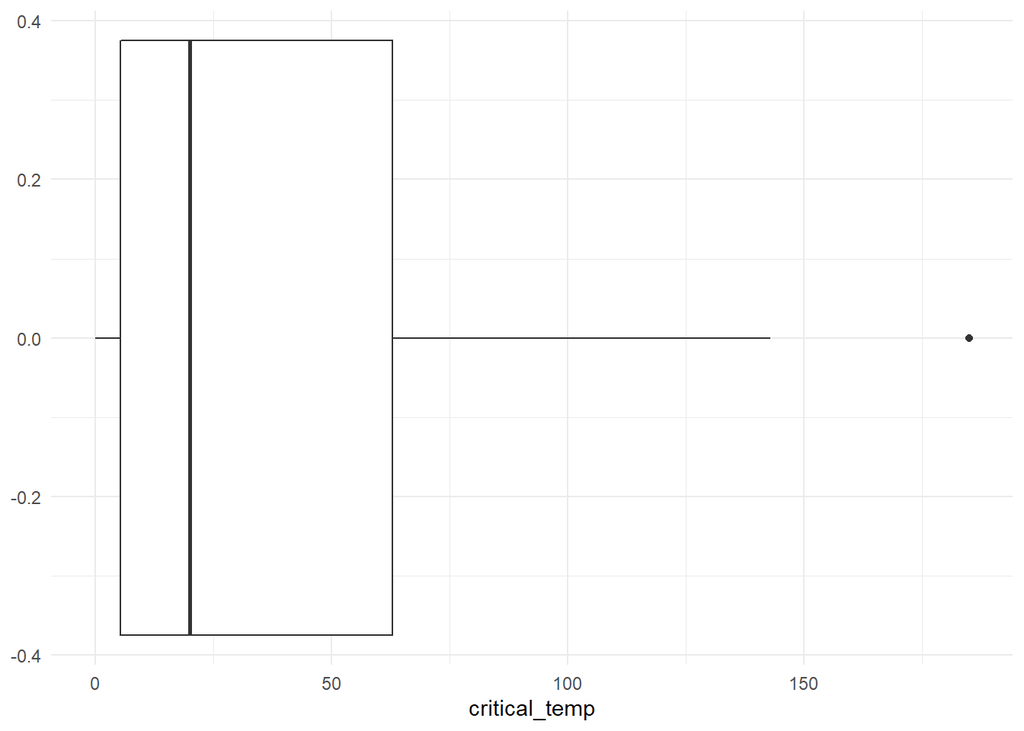

```r
ggplot(data, aes(x=critical_temp)) +
  geom_boxplot() +
  theme_minimal()
```

Seems like we have one outlier at >150. We will remove this observation

```r
data <- data %>% filter(critical_temp < 150)
```

Let’s look at descriptive statistics of each variable:

```r
ExpNumStat(data,by ="A",Outlier=TRUE,round= 2, gp = "critical_temp") %>%
  select(Vname, min, max, mean, median, SD, nOutliers)
```

```
##                               Vname    min      max    mean  median      SD
## 123                              Ag   0.00     7.00    0.01    0.00    0.17
## 91                               Al   0.00    99.92    0.06    0.00    1.13
## 110                              As   0.00    18.00    0.16    0.00    1.08
## 153                              Au   0.00    64.00    0.02    0.00    0.72
## 84                                B   0.00   105.00    0.14    0.00    1.04
## 131                              Ba   0.00    24.00    0.57    0.00    0.98
## 83                               Be   0.00    40.00    0.03    0.00    0.85
## 157                              Bi   0.00    14.00    0.20    0.00    0.66
## 112                              Br   0.00     5.00    0.00    0.00    0.08
## 85                                C   0.00   120.00    0.38    0.00    4.41
## 97                               Ca   0.00    24.00    0.26    0.00    0.90
## 124                              Cd   0.00   100.00    0.01    0.00    0.69
## 133                              Ce   0.00     5.00    0.03    0.00    0.17
## 95                               Cl   0.00     3.00    0.01    0.00    0.12
```

[output cut: 301 more lines]

We should look at the correlation between variables

```r
# Correlation

corr_simple <- function(df,sig=0.5){
  corr <- cor(df)
  #prepare to drop duplicates and correlations of 1
  corr[lower.tri(corr,diag=TRUE)] <- NA
  #drop perfect correlations
  corr[corr == 1] <- NA
  #turn into a 3-column table
  corr <- as.data.frame(as.table(corr))
  #remove the NA values from above
  corr <- na.omit(corr)
  #select significant values
  corr <- subset(corr, abs(Freq) > sig)
  #sort by highest correlation
  corr <- corr[order(-abs(corr$Freq)),]
  return(corr)
}

correlation_matrix = cor(data)
```

We have 4 variables with higher than .99 correlation. We have 22 variables with higher than .95 correlation. We have 35 variables with higher than .9 correlation.

# 4 Pre-process

## 4.1 Data split

```r
indices <- createDataPartition(data$critical_temp, p = 0.8, list = FALSE)
train <- data[indices,]
test <- data[-indices,]
```

Splitted a dataset by 80% / 20% rule. Created a training dataset with 17010 (80.0018813%) observations and testing dataset with 4252 (19.9981187%) observations.

## 4.2 Data transformation

```r
preProcValues <- preProcess(train, method = c("center", "scale"))
train_transformed <- predict(preProcValues, train)
test_transformed <- predict(preProcValues, test)

label_index <- which(colnames(train_transformed) == "critical_temp")
```

We also centered and scaled our data. We transformed the testing dataset based on the pre process of training dataset.

# 5 Linear Regression

## 5.1 Linear Regression - no changes in data

```r
# linear regression
train_control_cv <- trainControl(method = "cv", number = 10)
fit_lm <- train(critical_temp ~ ., data = train_transformed, method = "lm", trControl = train_control_cv)
```

We are performing linear regression model on the whole training dataset with 10 fold cross-validation. The model:

```r
print(fit_lm)
```

```
## Linear Regression
##
## 17010 samples
##   158 predictor
##
## No pre-processing
## Resampling: Cross-Validated (10 fold)
## Summary of sample sizes: 15309, 15309, 15310, 15309, 15309, 15307, ...
## Resampling results:
##
##   RMSE       Rsquared   MAE
##   0.5476384  0.7229608  0.3632821
##
## Tuning parameter 'intercept' was held constant at a value of TRUE
```

Our RMSE = 0.55, R^2 = 72%, MAE = 0.36

Using fitted linear regression model on the testing dataset:

```r
test_lm <- predict(fit_lm, newdata = test_transformed)
print(round(postResample(pred = test_lm, obs = test_transformed$critical_temp), 3))
```

```
##     RMSE Rsquared      MAE
##    1.180    0.306    0.380
```

Our model, on the testing dataset, only explains ~31% of variance, while on a training set the rsquared was 72%. But the MAE was 0.36 for the training set and 0.38 for the testing dataset, it could mean an outlier influences the RMSE and rqsuared.

Let’s look at the fitted vs actual plot:

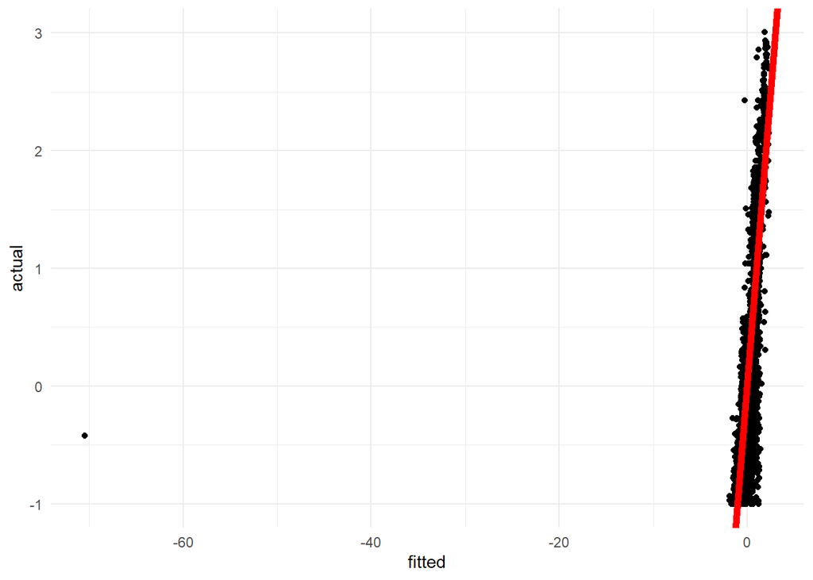

```r
fitted_actual_lm <- data.frame(fitted = test_lm, actual = test_transformed$critical_temp)

ggplot(fitted_actual_lm,
       aes(x = fitted,
           y = actual)) +
  geom_point() +
  geom_abline(intercept = 0,
              slope = 1,
              color = "red",
              size = 2) +
  theme_minimal()
```

We clearly see one value, with an actual value of ~-0.5, while the fitted value is ~-70.

Let’s look at that observation before transformation was applied:

```r
test[test_lm < -60,] %>%
  tidyr::pivot_longer(cols = everything())
```

```
## # A tibble: 159 x 2
##    name                       value
##    <chr>                      <dbl>
##  1 number_of_elements        4
##  2 mean_atomic_mass         90.1
##  3 wtd_mean_atomic_mass    138.
##  4 gmean_atomic_mass        66.9
##  5 wtd_gmean_atomic_mass   134.
##  6 entropy_atomic_mass       1.18
##  7 wtd_entropy_atomic_mass   0.0406
##  8 range_atomic_mass       125.
##  9 wtd_range_atomic_mass   137.
## 10 std_atomic_mass          53.1
## # ... with 149 more rows
```

If we would exclude this observation from our testing dataset:

```r
# without the outlier
print(round(postResample(pred = test_lm[test_lm > -60], obs = test_transformed$critical_temp[test_lm > -60]), 3))
```

```
##     RMSE Rsquared      MAE
##    0.489    0.759    0.364
```

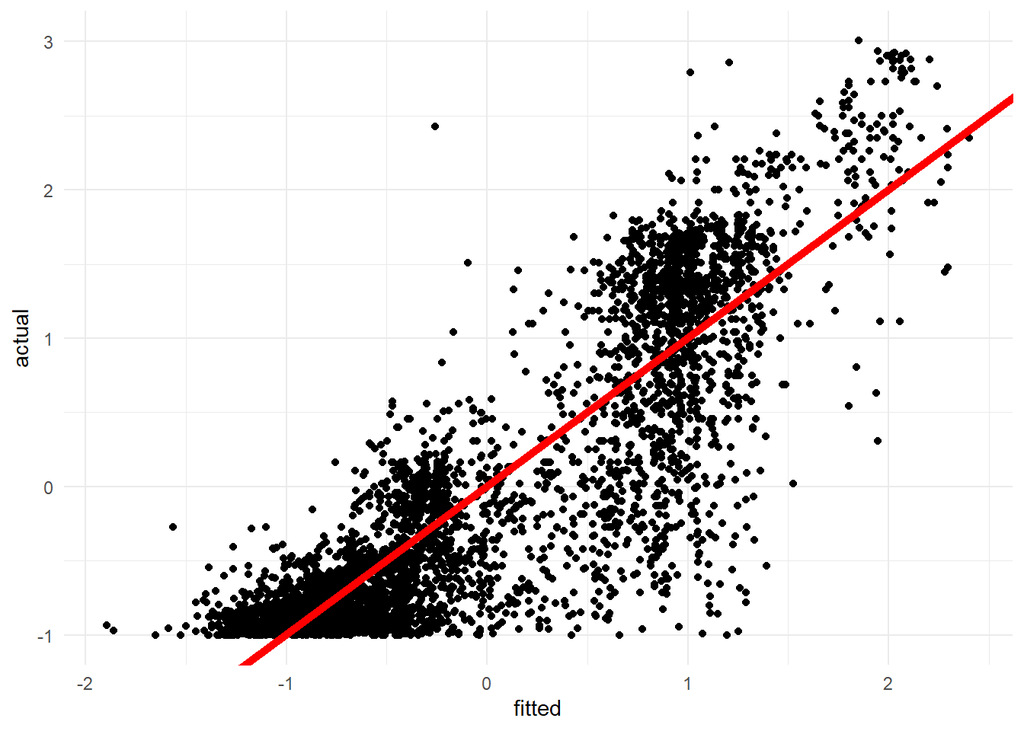

```r
ggplot(fitted_actual_lm %>% filter(fitted > -60),
       aes(x = fitted,
           y = actual)) +
  geom_point() +
  geom_abline(intercept = 0,
              slope = 1,
              color = "red",
              size = 2) +
  theme_minimal()
```

Our rsquared would be 76%, the MAE is 0.36 which is a reasonable result.

## 5.2 Linear Regression - removed correlated columns

```r
# Removed >.9 correlations
correlation_matrix = cor(train_transformed)
correlated_columns = findCorrelation(correlation_matrix, cutoff = 0.9)
correlated_columns = sort(correlated_columns)

colnames(train_transformed[, correlated_columns])
```

```
##  [1] "number_of_elements"          "gmean_atomic_mass"
##  [3] "wtd_gmean_atomic_mass"       "entropy_atomic_mass"
##  [5] "range_atomic_mass"           "wtd_std_atomic_mass"
##  [7] "mean_fie"                    "wtd_mean_fie"
##  [9] "entropy_fie"                 "range_fie"
## [11] "wtd_std_fie"                 "gmean_atomic_radius"
## [13] "wtd_gmean_atomic_radius"     "entropy_atomic_radius"
## [15] "wtd_entropy_atomic_radius"   "range_atomic_radius"
## [17] "wtd_std_atomic_radius"       "wtd_gmean_Density"
## [19] "range_Density"               "wtd_std_Density"
## [21] "range_ElectronAffinity"      "wtd_mean_FusionHeat"
## [23] "gmean_FusionHeat"            "wtd_gmean_FusionHeat"
## [25] "entropy_FusionHeat"          "std_FusionHeat"
## [27] "wtd_std_FusionHeat"          "range_ThermalConductivity"
## [29] "wtd_std_ThermalConductivity" "mean_Valence"
## [31] "wtd_mean_Valence"            "wtd_gmean_Valence"
## [33] "entropy_Valence"             "wtd_entropy_Valence"
## [35] "range_Valence"
```

We are going to remove these columns from our training dataset, those columns have >.9 correlation

```r
train_transformed_no_correlated = train_transformed[,-c(correlated_columns)]
label_index_noCorr <- which(colnames(train_transformed_no_correlated) == "critical_temp")
fit_lm_no_correlated <- train(critical_temp ~ ., data = train_transformed_no_correlated, method = "lm", trControl = train_control_cv)
```

Performing Linear Regression with 10 fold cross-validation

```r
print(fit_lm_no_correlated)
```

```
## Linear Regression
##
## 17010 samples
##   123 predictor
##
## No pre-processing
## Resampling: Cross-Validated (10 fold)
## Summary of sample sizes: 15310, 15310, 15309, 15309, 15309, 15309, ...
## Resampling results:
##
##   RMSE       Rsquared   MAE
##   0.5921099  0.6957537  0.379391
##
## Tuning parameter 'intercept' was held constant at a value of TRUE
```

We see, that our rsquared on training dataset dropped to 70% and MAE increased to 0.38.

Testing on a test dataset

```r
test_lm_noCorr <- predict(fit_lm_no_correlated, newdata = test_transformed[, -c(correlated_columns, label_index)])
round(postResample(pred = test_lm_noCorr, obs = test_transformed$critical_temp), 3)
```

```
##     RMSE Rsquared      MAE
##    0.925    0.416    0.391
```

Rsquared on the testing dataset is 42% while MAE is 0.39 and RMSE = 0.93, let’s look at the plot

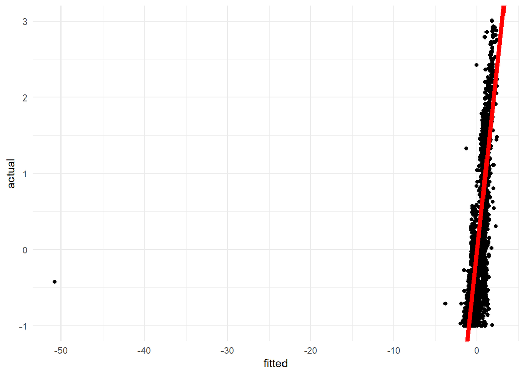

```r
fitted_actual_lm_noCorr <- data.frame(fitted = test_lm_noCorr, actual = test_transformed$critical_temp)

ggplot(fitted_actual_lm_noCorr,
       aes(x = fitted,
           y = actual)) +
  geom_point() +
  geom_abline(intercept = 0,
              slope = 1,
              color = "red",
              size = 2) +
  theme_minimal()
```

Same result with that one outlier.

## 5.3 Ridge Linear Regression

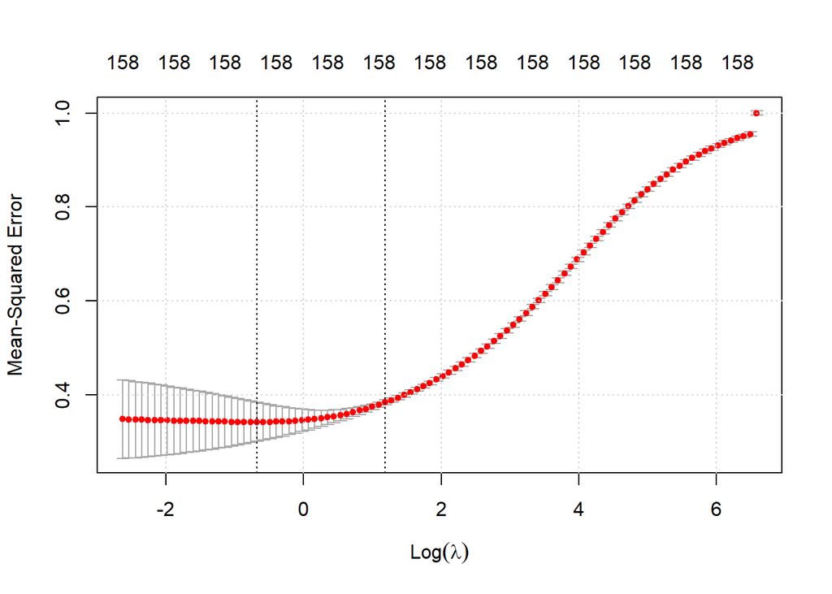

```r
fit_lmridge_cv = cv.glmnet(as.matrix(train_transformed[, -label_index]), train_transformed[, label_index], alpha = 0, nfolds = 10, family = 'gaussian')
plot(fit_lmridge_cv)
grid()
```

Best minimum lambda is:

```r
fit_lmridge_cv$lambda.min
```

```
## [1] 0.5091288
```

```r
fit_lmridge = glmnet(as.matrix(train_transformed[, -label_index]), train_transformed[, label_index], lambda = fit_lmridge_cv$lambda.min)
test_lmridge <- predict(fit_lmridge, as.matrix(test_transformed[, -label_index]))
round(postResample(pred = test_lmridge, obs = test_transformed$critical_temp), 3)
```

```
##     RMSE Rsquared      MAE
##    0.854    0.523    0.721
```

Let’s plot fitted vs actual values:

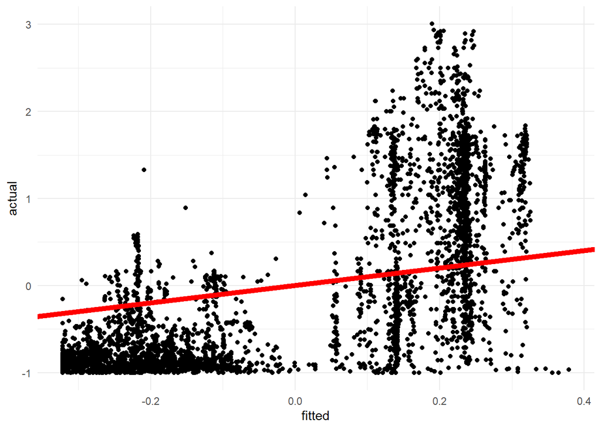

```r
fitted_actual_lmridge <- data.frame(fitted = test_lmridge, actual = test_transformed$critical_temp) %>%
  rename(fitted = s0)

ggplot(fitted_actual_lmridge,
       aes(x = fitted,
           y = actual)) +
  geom_point() +
  geom_abline(intercept = 0,
              slope = 1,
              color = "red",
              size = 2) +
  theme_minimal()
```

Our Ridge Linear Regression model does not look like a good prediction model.

## 5.4 Lasso Linear Regression

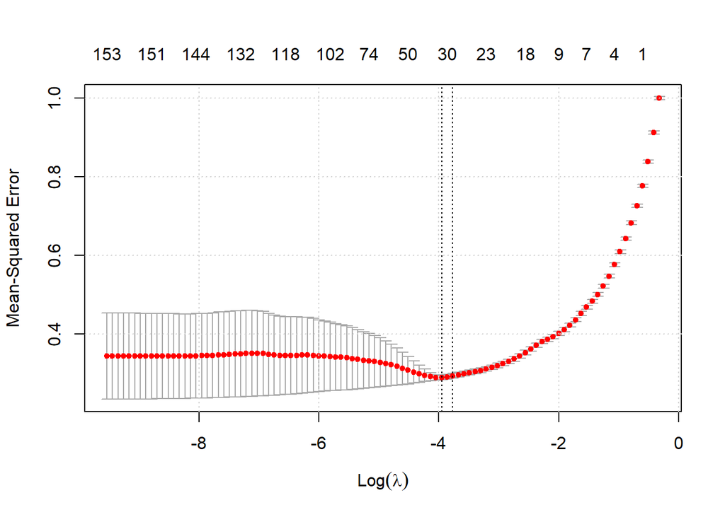

```r
fit_lasso_cv = cv.glmnet(as.matrix(train_transformed[, -label_index]), train_transformed[, label_index], alpha = 1, nfolds = 10, family = 'gaussian')
plot(fit_lasso_cv)
grid()
```

Best minimum lambda is:

```r
fit_lasso_cv$lambda.min
```

```
## [1] 0.01916837
```

Let’s fit a Lasso Linear Regression using best minimum lambda:

```r
fit_lasso = glmnet(as.matrix(train_transformed[, -label_index]), train_transformed[, label_index], lambda = fit_lasso_cv$lambda.min)
test_lasso <- predict(fit_lasso, as.matrix(test_transformed[, -label_index]))
round(postResample(pred = test_lasso, obs = test_transformed$critical_temp), 3)
```

```
##     RMSE Rsquared      MAE
##    0.939    0.371    0.418
```

Using Lasso Linear Regression we obtained 37% Rsquared, 0.41 MAE and 0.94 RMSE on testing dataset.

Let’s plot fitted vs actual values:

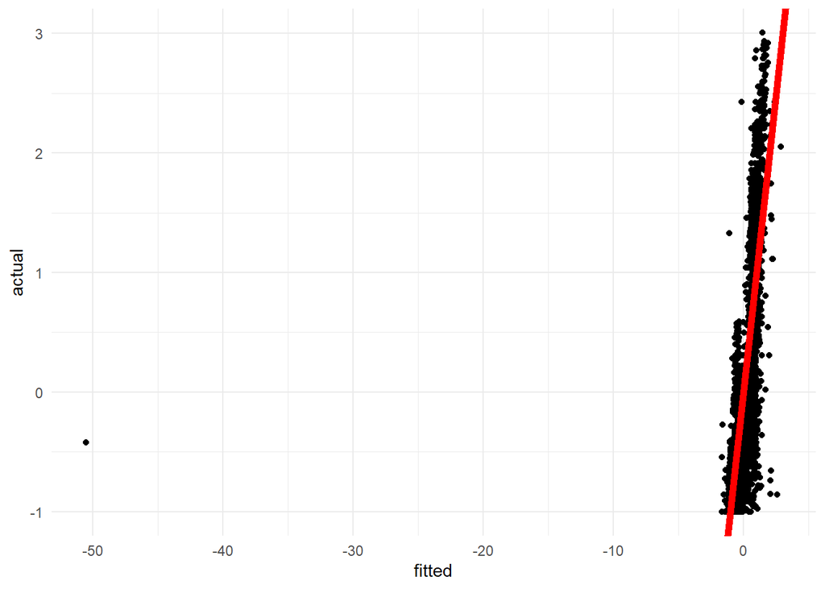

```r
fitted_actual_lasso <- data.frame(fitted = test_lasso, actual = test_transformed$critical_temp) %>%
  rename(fitted = s0)

ggplot(fitted_actual_lasso,
       aes(x = fitted,
           y = actual)) +
  geom_point() +
  geom_abline(intercept = 0,
              slope = 1,
              color = "red",
              size = 2) +
  theme_minimal()
```

We see the same predicted outlier

## 5.5 Elastic Net Regression

```r
fit_elasticNet <- train(critical_temp ~ ., data = train_transformed, method = "glmnet", trControl = train_control_cv, tuneLength = 10)

print(fit_elasticNet)
```

```
## glmnet
##
## 17010 samples
##   158 predictor
##
## No pre-processing
## Resampling: Cross-Validated (10 fold)
## Summary of sample sizes: 15309, 15308, 15310, 15309, 15308, 15309, ...
## Resampling results across tuning parameters:
##
##   alpha  lambda        RMSE       Rsquared   MAE
##   0.1    0.0003334334  0.5521809  0.7193294  0.3649076
##   0.1    0.0007702743  0.5522658  0.7192238  0.3649629
##   0.1    0.0017794336  0.5545260  0.7169534  0.3661600
##   0.1    0.0041107225  0.5590509  0.7127377  0.3685153
##   0.1    0.0094963024  0.5597657  0.7090862  0.3719233
##   0.1    0.0219376907  0.5604106  0.7040964  0.3778729
##   0.1    0.0506789121  0.5592158  0.6997338  0.3863189
##   0.1    0.1170748628  0.5498485  0.7009994  0.4030787
##   0.1    0.2704581245  0.5607061  0.6927732  0.4273265
##   0.1    0.6247933616  0.6056380  0.6537335  0.4700689
##   0.2    0.0003334334  0.5519383  0.7198446  0.3646780
##   0.2    0.0007702743  0.5527009  0.7188167  0.3652199
##   0.2    0.0017794336  0.5563327  0.7155850  0.3668772
##   0.2    0.0041107225  0.5590409  0.7114180  0.3698067
##   0.2    0.0094963024  0.5603548  0.7065805  0.3747921
##   0.2    0.0219376907  0.5607752  0.7013897  0.3816803
##   0.2    0.0506789121  0.5515384  0.7012231  0.3950047
##   0.2    0.1170748628  0.5474042  0.7046765  0.4131781
##   0.2    0.2704581245  0.5831226  0.6737630  0.4477594
##   0.2    0.6247933616  0.6484289  0.6219819  0.5084315
##   0.3    0.0003334334  0.5513567  0.7200799  0.3646204
##   0.3    0.0007702743  0.5527408  0.7185293  0.3654303
##   0.3    0.0017794336  0.5575213  0.7143876  0.3676158
##   0.3    0.0041107225  0.5580076  0.7108241  0.3707994
##   0.3    0.0094963024  0.5612338  0.7041247  0.3774650
##   0.3    0.0219376907  0.5601104  0.6993409  0.3860775
##   0.3    0.0506789121  0.5424114  0.7078329  0.4006299
##   0.3    0.1170748628  0.5566857  0.6968250  0.4213747
##   0.3    0.2704581245  0.6077080  0.6510514  0.4694203
```

[output cut: 59 more lines]

```
##   0.9    0.2704581245  0.7003066  0.5898256  0.5584944
##   0.9    0.6247933616  0.8976460  0.5211803  0.7602418
##   1.0    0.0003334334  0.5519935  0.7189174  0.3654389
##   1.0    0.0007702743  0.5578343  0.7140175  0.3679050
##   1.0    0.0017794336  0.5598592  0.7092525  0.3720341
##   1.0    0.0041107225  0.5629040  0.7024430  0.3790233
##   1.0    0.0094963024  0.5562527  0.7002069  0.3892984
##   1.0    0.0219376907  0.5409921  0.7094397  0.4052670
##   1.0    0.0506789121  0.5676839  0.6852420  0.4301046
##   1.0    0.1170748628  0.6243707  0.6334658  0.4833076
##   1.0    0.2704581245  0.7140457  0.5809629  0.5736239
##   1.0    0.6247933616  0.9324051  0.5211803  0.7931457
##
## RMSE was used to select the optimal model using the smallest value.
## The final values used for the model were alpha = 0.9 and lambda = 0.02193769.
```

Best parameters:

```r
fit_elasticNet$bestTune
```

```
##    alpha     lambda
## 86   0.9 0.02193769
```

Testing on a test dataset

```r
test_elasticNet <- predict(fit_elasticNet, newdata = test_transformed[, -label_index])
round(postResample(pred = test_elasticNet, obs = test_transformed$critical_temp), 3)
```

```
##     RMSE Rsquared      MAE
##    0.938    0.371    0.419
```

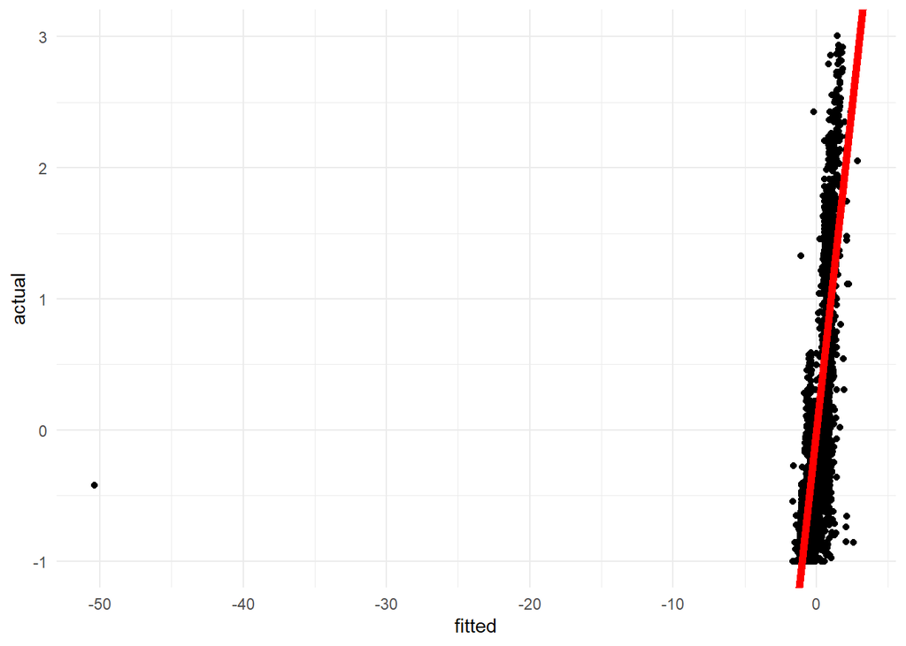

```r
fitted_actual_elasticNet <- data.frame(fitted = test_elasticNet, actual = test_transformed$critical_temp)

ggplot(fitted_actual_elasticNet,
       aes(x = fitted,
           y = actual)) +
  geom_point() +
  geom_abline(intercept = 0,
              slope = 1,
              color = "red",
              size = 2) +
  theme_minimal()
```

# 6 Conclusion

```r
models <- t(data.frame(
  `Linear Regression` = round(postResample(pred = test_lm, obs = test_transformed$critical_temp), 3),
  `Linear Regression Without Correlated Columns` = round(postResample(pred = test_lm_noCorr, obs = test_transformed$critical_temp), 3),
  `RIDGE` = round(postResample(pred = test_lmridge, obs = test_transformed$critical_temp), 3),
  `LASSO` = round(postResample(pred = test_lasso, obs = test_transformed$critical_temp), 3),
  `Elastic Net Regression` = round(postResample(pred = test_elasticNet, obs = test_transformed$critical_temp), 3)
))

print(models)
```

```
##                                               RMSE Rsquared   MAE
## Linear.Regression                            1.180    0.306 0.380
## Linear.Regression.Without.Correlated.Columns 0.925    0.416 0.391
## RIDGE                                        0.854    0.523 0.721
## LASSO                                        0.939    0.371 0.418
## Elastic.Net.Regression                       0.938    0.371 0.419
```

The best result was achieved using RIDGE linear regression, while the MAE of Ridge is the highest, Ridge method did not produced outlier prediction, unlike other methods.